# Pandas_Plot

#### Autocorrelation Plot

- Compute correlation coefficiencies for data values at varying time lags, lag vs Series.autocorr()
- Random, autocorrelations should be near zero
- Non-random, autocorrelations will be significantly non-zero

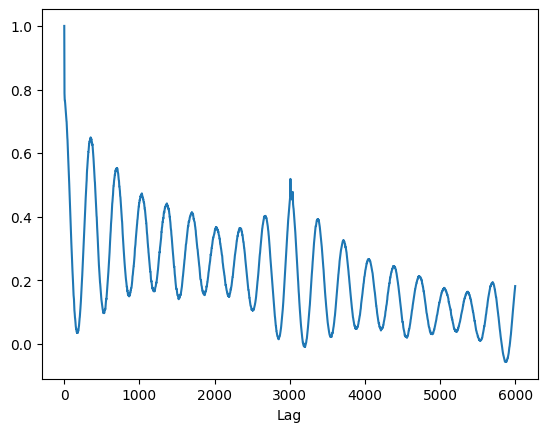

```python
# Manually calculate correlation coefficiencies for each lag value
correlations = []
for i in range(6000):
    correlations.append(data['MinTemp'].autocorr(lag=i))
s = pd.Series(correlations)
ax = s.plot()
ax.set_xlabel('Lag')
```

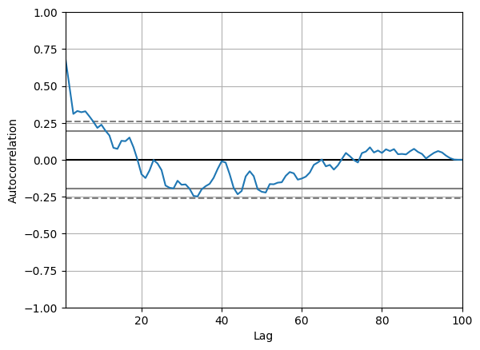

```python
# Use autocorrelation plot
# If there is any missed value, autocorrelation plot does not plot
from pandas.plotting import autocorrelation_plot
ax = autocorrelation_plot(data.iloc[:100, :]['MinTemp'])
```

#### Bootstrap Plot

- Sample a random subset of a specified size from a data set, calculate mean, median, midrange, etc.
- Repeat the sampling many times to plot the distributions of mean, median, and midrange.

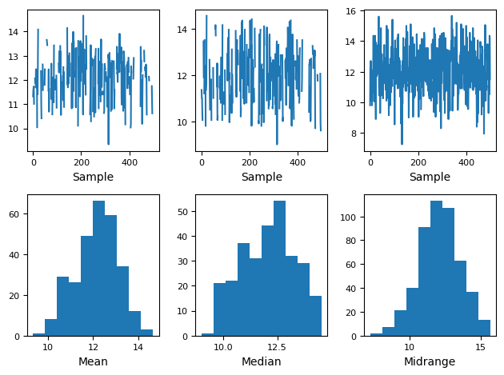

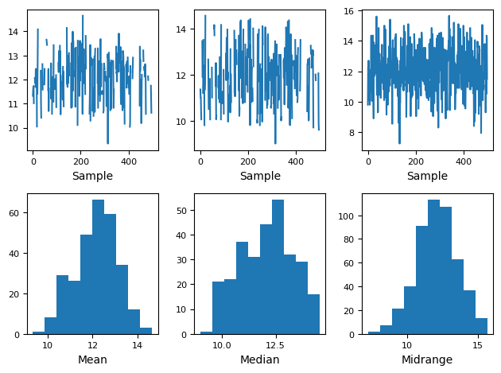

```python
from pandas.plotting import bootstrap_plot

# size, number of data points in each sampling
# samples, number of times of sampling
bootstrap_plot(data['MinTemp'], size=50, samples=500)
```

#### RadViz

- A multivariate data visualization algorithm
- Plots each feature dimension uniformly around the circumference of a circle
- Each point normalizes its attributes on the axes from the center to each arc

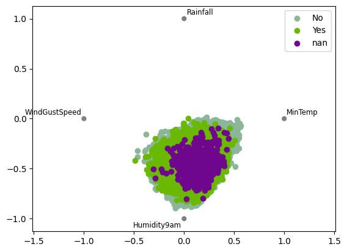

```python
from pandas.plotting import radviz
radviz(data[['MinTemp', 'Rainfall', 'WindGustSpeed', 'Humidity9am', 'RainTomorrow']], 'RainTomorrow')
```

#### Reference

- [Simple Introduction to Andrews Curves with Python](https://towardsdatascience.com/simple-introduction-to-andrews-curves-with-python-e20d0620ed6b)
- [Pandas Plot: Deep Dive Into Plotting Directly With Pandas](https://neptune.ai/blog/pandas-plot-deep-dive-into-plotting-directly-with-pandas)
- [Pandas API](https://pandas.pydata.org/docs/reference/)
- [Tutorial](https://pandas.pydata.org/pandas-docs/version/0.18.1/visualization.html)